# MCEM part2

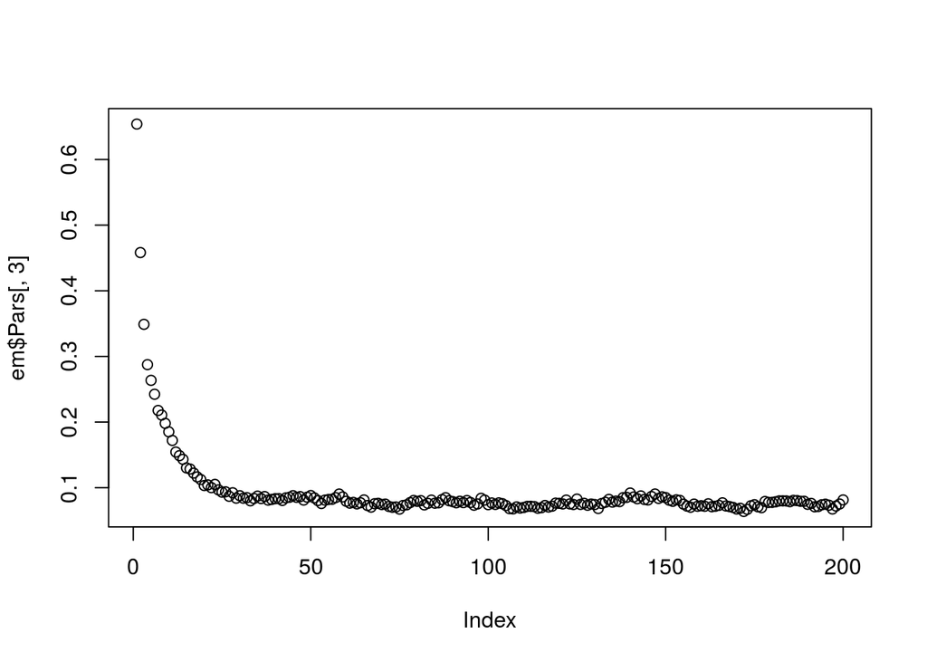

```r
plot(em$Pars[,3])
```

or

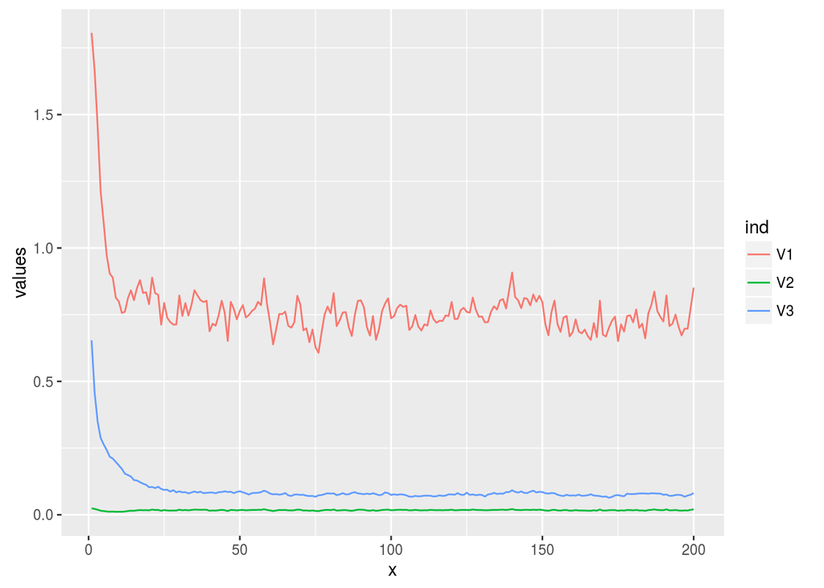

```r
sa <- stack(as.data.frame(em$Pars))
sa$x <- rep(seq_len(nrow(em$Pars)), ncol(em$Pars))
qplot(x, values, data = sa, group = ind, colour = ind, geom = "line")
```

and

```r
summary(tail(em$Pars[,3],n = 100))
```

```
##    Min. 1st Qu.  Median    Mean 3rd Qu.    Max.
## 0.06386 0.07174 0.07518 0.07592 0.07970 0.09192
```

```r
summary(tail(em$Pars[,1],n = 100))
```

```
##    Min. 1st Qu.  Median    Mean 3rd Qu.    Max.
##  0.6508  0.7071  0.7431  0.7445  0.7767  0.9081
```

if we (cheat less and) do not take the perfect adjustment?

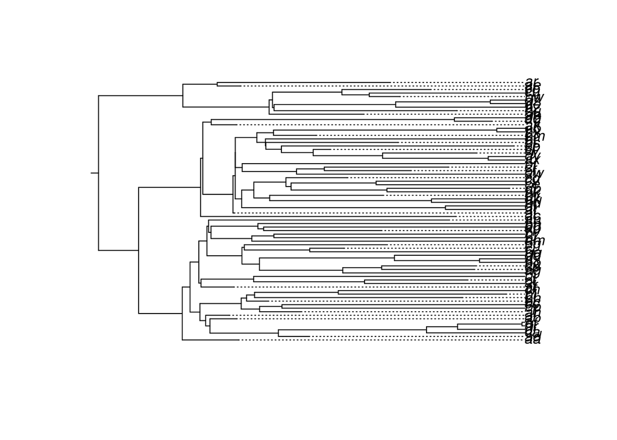

```r
st <- sim_phyl()
plot(st$newick,align.tip.label=T,root.edge=T)
```

```r
st2 <- phylo2p(drop.fossil(st$newick))
em <- EM_phylo(wt=st2$t,init_par=c(1.6,0.02,1.2),n_trees=10,dummy=(0.1-0.08918)/2,n_it = 400,printpar = F)
```

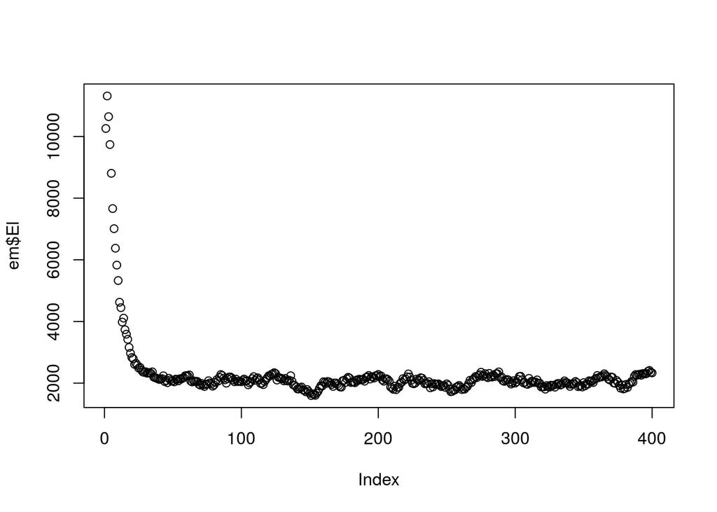

```r
plot(em$El)
```

the parameters

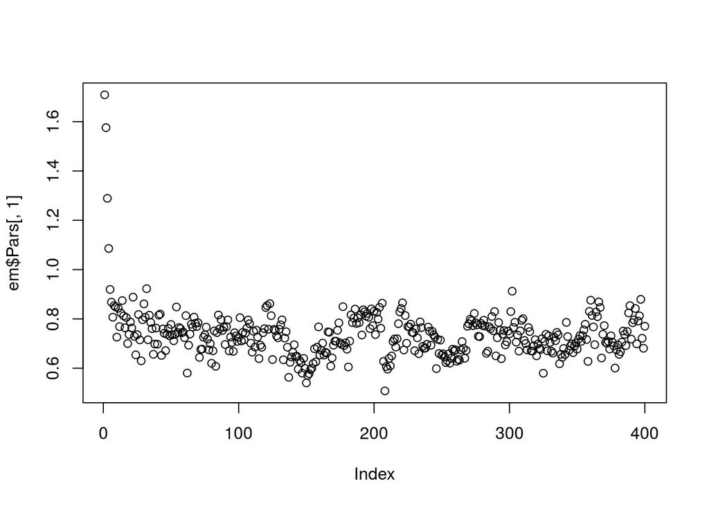

```r
plot(em$Pars[,1])
```

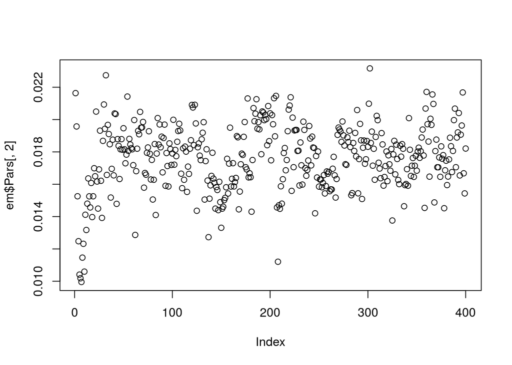

```r
plot(em$Pars[,2])
```

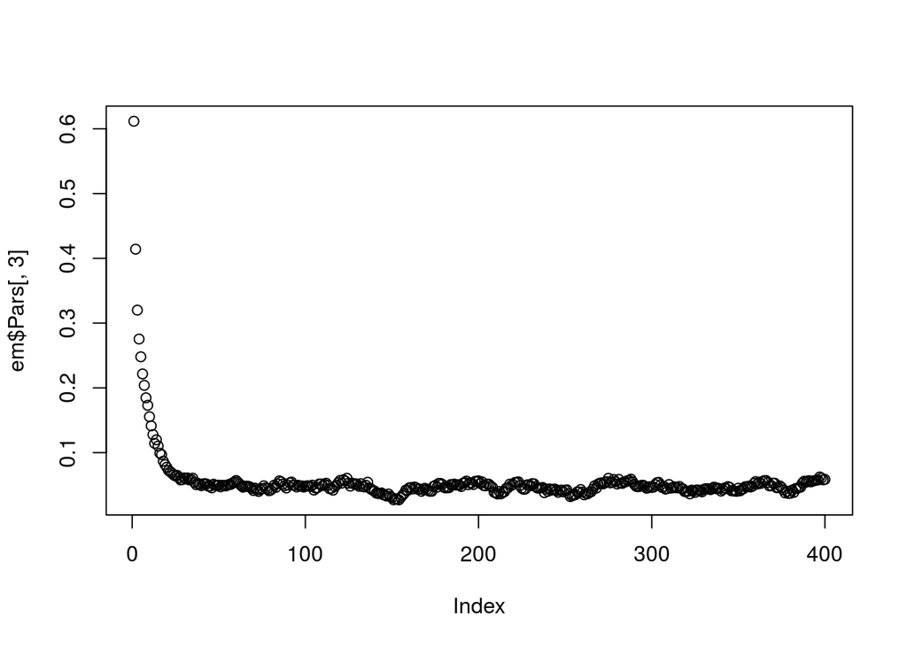

```r
plot(em$Pars[,3])
```

or

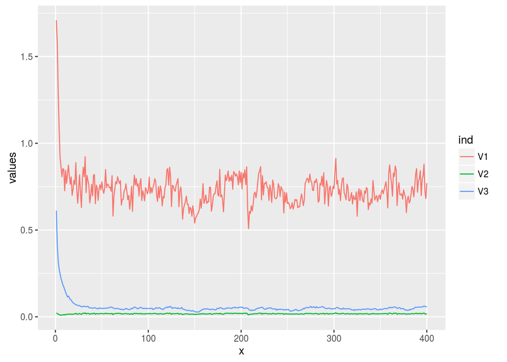

```r
sa <- stack(as.data.frame(em$Pars))
sa$x <- rep(seq_len(nrow(em$Pars)), ncol(em$Pars))
qplot(x, values, data = sa, group = ind, colour = ind, geom = "line")
```

and

```r
summary(tail(em$Pars[,3],n = 200))
```

```
##    Min. 1st Qu.  Median    Mean 3rd Qu.    Max.
## 0.03214 0.04211 0.04618 0.04688 0.05188 0.06239
```

```r
summary(tail(em$Pars[,1],n = 200))
```

```
##    Min. 1st Qu.  Median    Mean 3rd Qu.    Max.
##  0.5079  0.6744  0.7179  0.7233  0.7690  0.9126
```

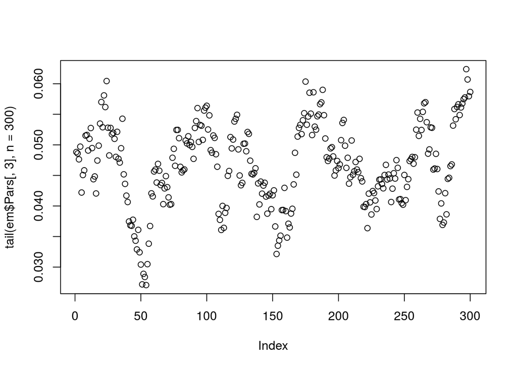

```r
plot(tail(em$Pars[,3],n = 300))
```

it`s weird, it was suppose to go to zero, but it also stabilized the EM iterations.

let`s see if for a minimal dummy value we still have this

if we (cheat less and) do not take the perfect adjustment?

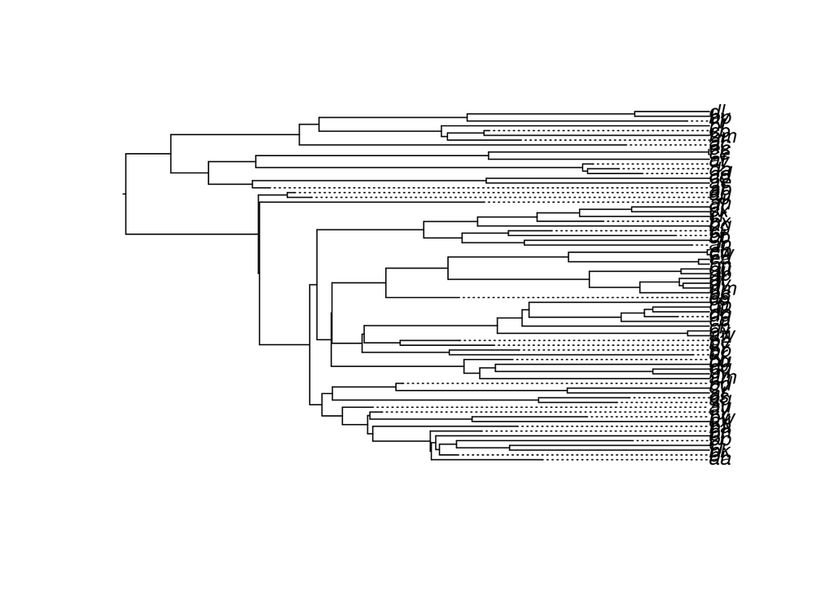

```r
st <- sim_phyl()
plot(st$newick,align.tip.label=T,root.edge=T)
```

```r
st2 <- phylo2p(drop.fossil(st$newick))
em <- EM_phylo(wt=st2$t,init_par=c(1.6,0.02,1.2),n_trees=10,dummy=0.00001,n_it = 400,printpar = F)
```

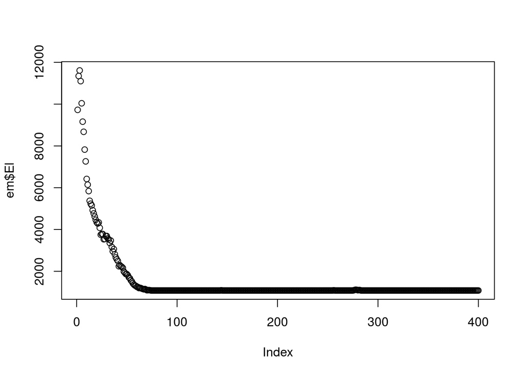

```r
plot(em$El)
```

the parameters

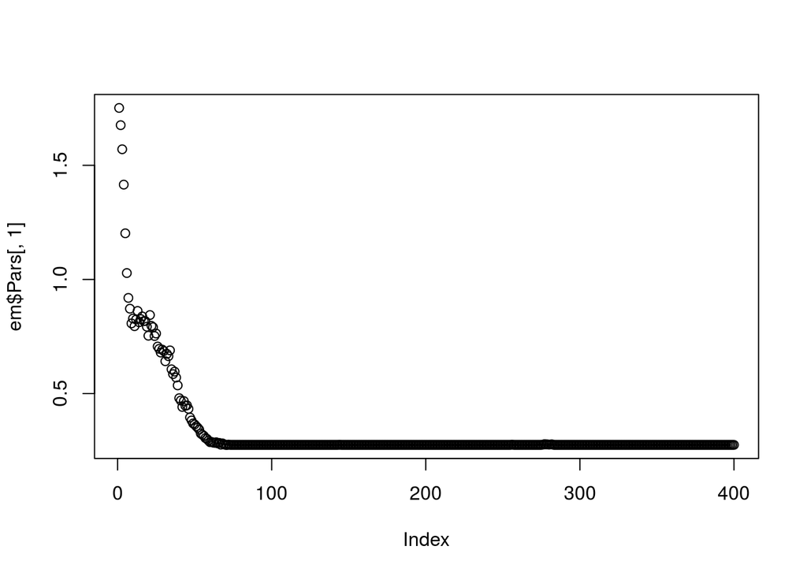

```r
plot(em$Pars[,1])
```

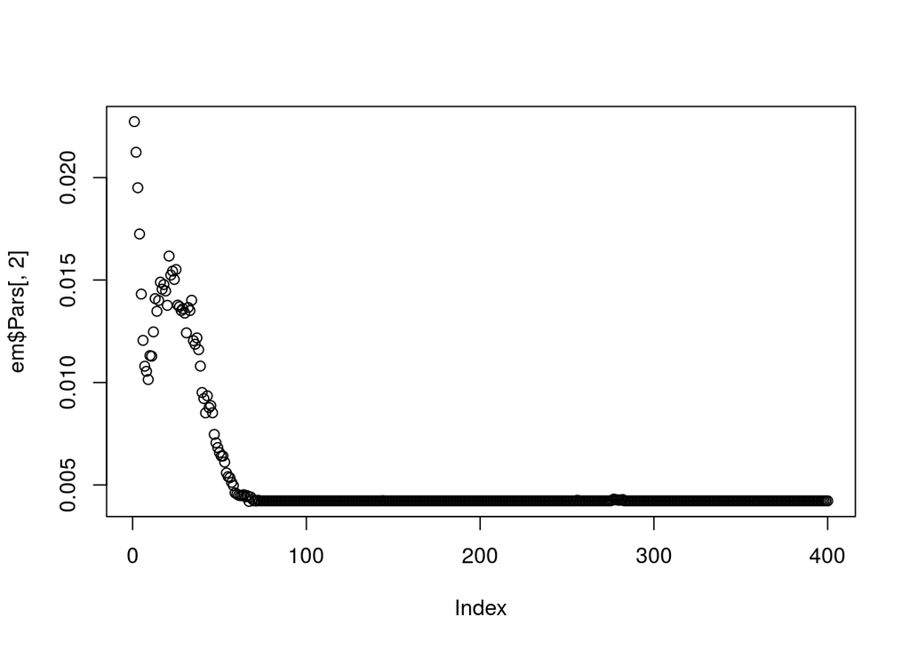

```r
plot(em$Pars[,2])
```

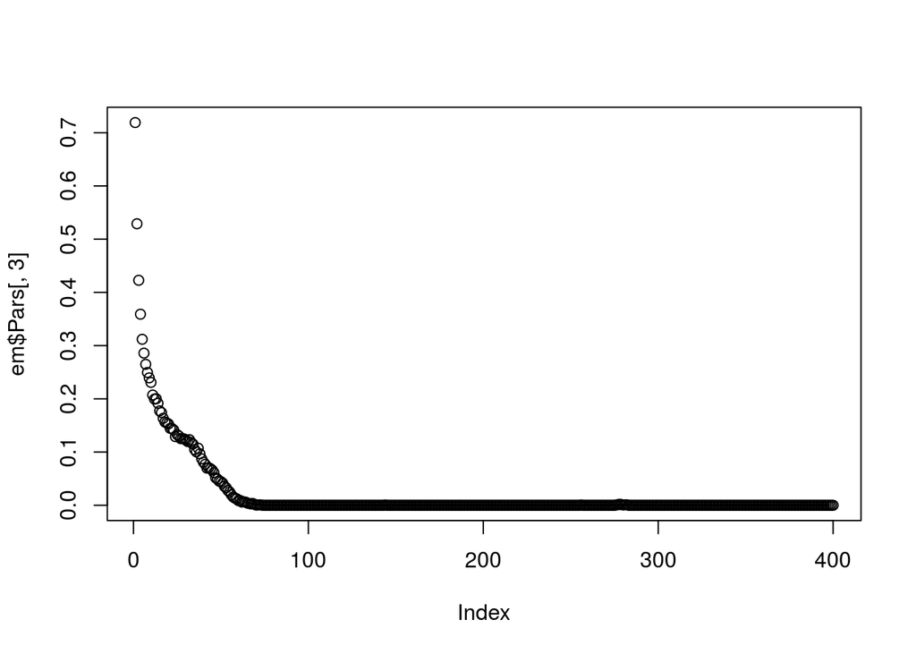

```r
plot(em$Pars[,3])
```

or

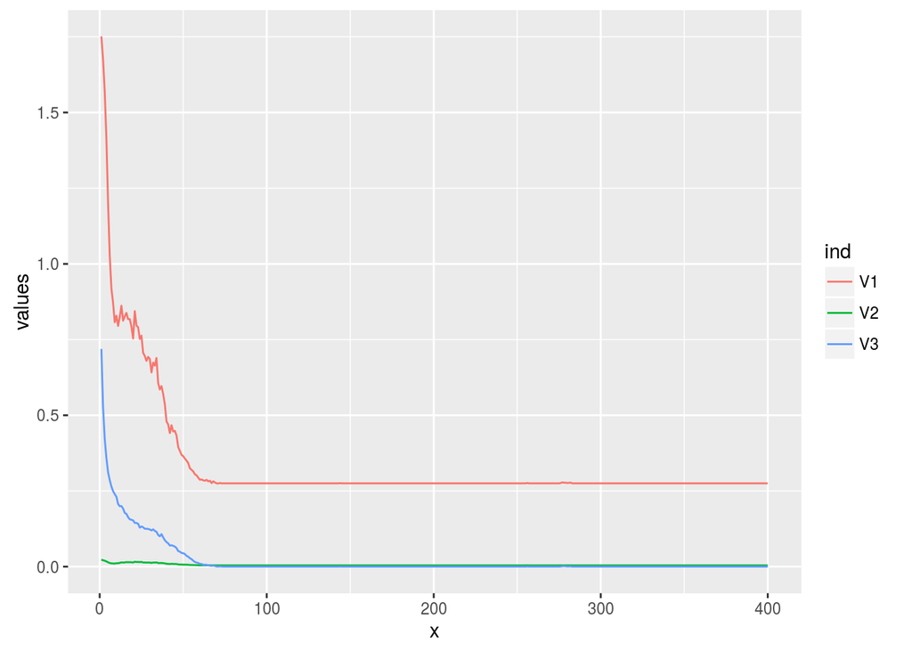

```r
sa <- stack(as.data.frame(em$Pars))
sa$x <- rep(seq_len(nrow(em$Pars)), ncol(em$Pars))
qplot(x, values, data = sa, group = ind, colour = ind, geom = "line")
```

and

```r
summary(tail(em$Pars[,3],n = 200))
```

```
##      Min.   1st Qu.    Median      Mean   3rd Qu.      Max.
## 0.000e+00 0.000e+00 0.000e+00 3.713e-05 0.000e+00 1.742e-03
```

```r
summary(tail(em$Pars[,1],n = 200))
```

```
##    Min. 1st Qu.  Median    Mean 3rd Qu.    Max.
##  0.2752  0.2752  0.2752  0.2753  0.2752  0.2782
```

ok, not anymore.. ***

let´s see for bigger numbers

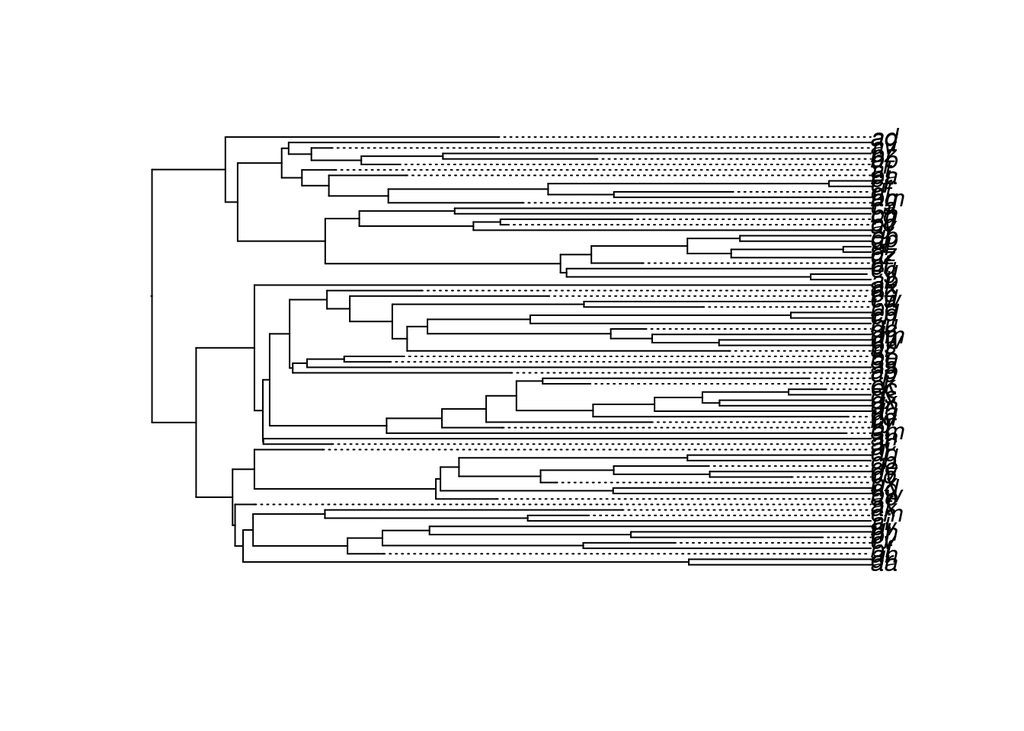

```r
st <- sim_phyl()
plot(st$newick,align.tip.label=T,root.edge=T)
```

```r
st2 <- phylo2p(drop.fossil(st$newick))
em <- EM_phylo(wt=st2$t,init_par=c(1.6,0.02,1.2),n_trees=10,dummy=0.2, n_it = 400,printpar = F)
```

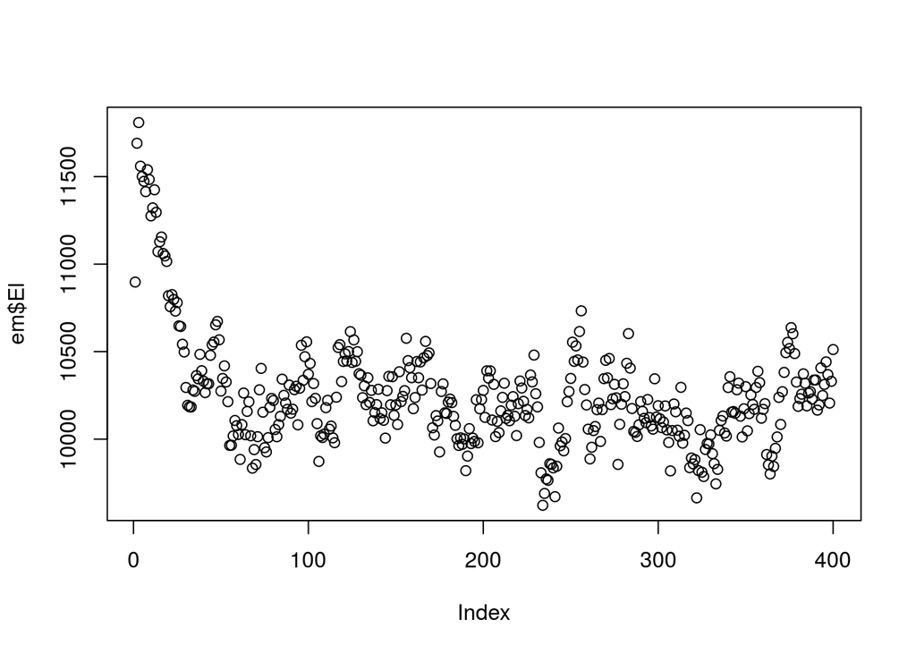

```r
plot(em$El)
```

the parameters

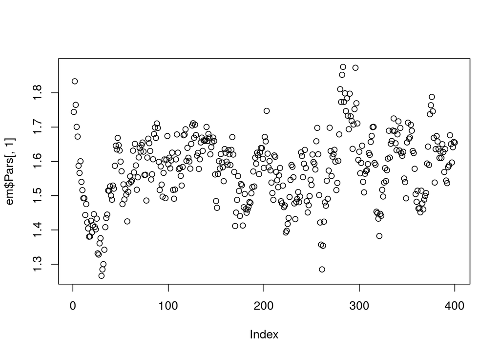

```r
plot(em$Pars[,1])
```

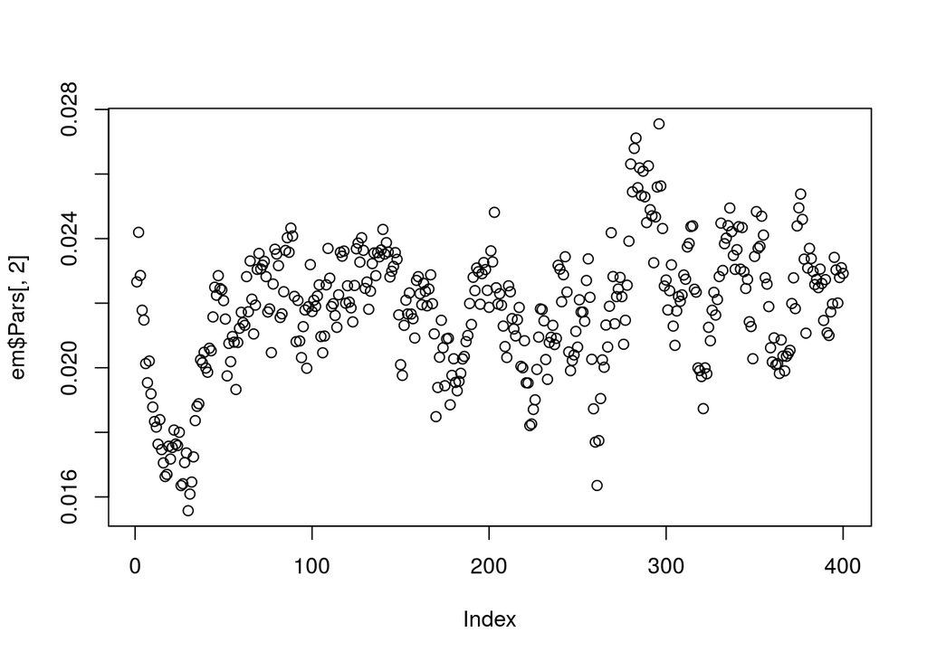

```r
plot(em$Pars[,2])
```

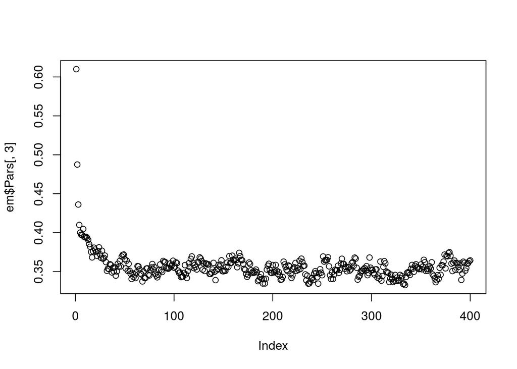

```r
plot(em$Pars[,3])
```

or

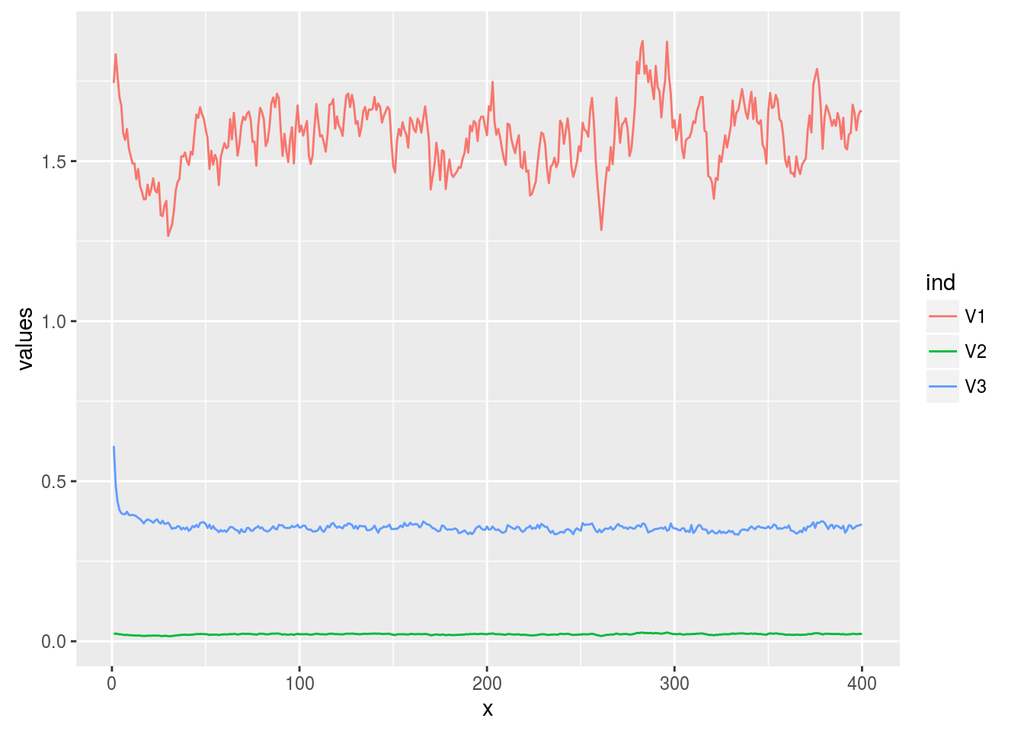

```r
sa <- stack(as.data.frame(em$Pars))
sa$x <- rep(seq_len(nrow(em$Pars)), ncol(em$Pars))
qplot(x, values, data = sa, group = ind, colour = ind, geom = "line")
```

and

```r
summary(tail(em$Pars[,3],n = 200))
```

```
##    Min. 1st Qu.  Median    Mean 3rd Qu.    Max.
##  0.3326  0.3454  0.3522  0.3520  0.3584  0.3749
```

```r
summary(tail(em$Pars[,1],n = 200))
```

```
##    Min. 1st Qu.  Median    Mean 3rd Qu.    Max.
##   1.285   1.513   1.594   1.592   1.657   1.876
```